# Creating Documents from Wikipedia Pages and Applying Latent Topic Modelling

Below code installs all the necessary packages:

```r
suppressPackageStartupMessages({
  if (!require(rvest)){ install.packages("rvest")}; library(rvest)
})
suppressPackageStartupMessages({
  if (!require(tm)){ install.packages("tm")}; library(tm)
})
suppressPackageStartupMessages({
  if (!require(tokenizers)){ install.packages("tokenizers")}; library(tokenizers)
})
suppressPackageStartupMessages({
  if (!require(tidyverse)){ install.packages("tidyverse")}; library(tidyverse)
})
suppressPackageStartupMessages({
  if (!require(tidytext)){ install.packages("tidytext")}; library(tidytext)
})
suppressPackageStartupMessages({
  if (!require(stringr)){ install.packages("stringr")}; library(stringr)
})
suppressPackageStartupMessages({
  if (!require(topicmodels)){ install.packages("topicmodels")}; library(topicmodels)
})

suppressPackageStartupMessages({
  if (!require(ggplot2)){ install.packages("ggplot2")}; library(ggplot2)
})
```

The below piece of code is creating a function ‘getSentencesFrmWikiPages’, taking wikipedia URLs as argument, and tokenizing them to sentences.

```r
getSentencesFrmWikiPages <- function(url)
{
  pagetext <- vector()
  wikipagetext <- read_html(url)
  paragraphs <- wikipagetext %>% html_nodes(xpath = "//p")

  for(paragraph in paragraphs)
  {
    p.text <- paragraph %>% html_text()
    pagetext<- c(pagetext,p.text)

  }
  pagetext <- gsub("[^a-zA-Z\\.']+", " ", pagetext )
  sentences <- tokenize_sentences(pagetext)
  return (sentences)
}
```

The below portion of code is taking 4 wikipedia pages which are of different domains, and assigning them to 4 different objects - wikipage1, wikipage2, wikipage3, and wikipage4.

Then, creating a vector - wikipages, concatenating all the above 4 objects.

Then, creating 4 more objects containing sentences from 4 wikipedia pages.

After that, creating a list comprising of all the sentences of 4 Wikipedia pages.

```r
wikipage1 <- "https://en.wikipedia.org/wiki/Mahatma_Gandhi"
wikipage2 <- "https://en.wikipedia.org/wiki/Apple_Inc."
wikipage3 <- "https://en.wikipedia.org/wiki/Roger_Federer"
wikipage4 <- "https://en.wikipedia.org/wiki/Singapore"

wikipages <- c(wikipage1, wikipage2, wikipage3, wikipage4)

wikiMahatmaGandhi <- unlist(getSentencesFrmWikiPages(wikipage1), recursive = TRUE, use.names = TRUE)
wikiApple <- unlist(getSentencesFrmWikiPages(wikipage2), recursive = TRUE, use.names = TRUE)
wikiRogerFederer <- unlist(getSentencesFrmWikiPages(wikipage3), recursive = TRUE, use.names = TRUE)
wikiSingapore <- unlist(getSentencesFrmWikiPages(wikipage4), recursive = TRUE, use.names = TRUE)
wikiList <- list(wikiMahatmaGandhi, wikiApple, wikiRogerFederer, wikiSingapore)

distScale <- list(c(0,0,0,8),c(0,0,4,4),c(0,0,8,0),c(0,2,2,4),c(0,2,4,2),c(0,4,0,4),c(0,4,2,2),c(0,4,4,0),c(0,8,0,0),c(2,0,2,4),c(2,0,4,2),c(2,2,0,4),
               c(2,2,2,2),c(2,2,4,0),c(2,4,0,2),c(2,4,2,0),c(4,0,0,4),c(4,0,2,2),c(4,0,4,0),c(4,2,0,2),c(4,2,2,0),c(4,4,0,0),c(8,0,0,0))
```

The following chunk of code is creating a data frame - dfdocs of 9 variables consisting of sentences from different documents. This is to preserve the ratio of sentence distribution along with this we are creating another data frame for LTM - dfforLTM containing 3 columns - id, text, and title.

randompicks function will randomly pick one of the sentences ratio from distScale and rselwikilist will contain the appropriate sentences from any one of the 4 wikipedia pages appropriately. Suppose we have choosen vector (0,0,0,8), then rselwikilist will be containing 8 sentences from Wikipedia page Singapore.

Now, sentcsel will contain all the sentences from all the documents. and then, dfforLTM will be having 1 row having values for 3 variables id, text, and document name i.e. title.

```r
dfdocs <- data.frame(matrix(ncol = 9, nrow = 0), stringsAsFactors = F)
dfforLTM <- data.frame(matrix(ncol = 3, nrow = 0), stringsAsFactors = F)
colnames(dfforLTM) <- c("id", "text", "title")
docNames <- c("MahatmaGandhi", "Apple", "RogerFederer",  "Singapore")
colnames(dfdocs) <- c("DocNum", "MahatmaGandhi", "MGPorp", "Apple", "AppPorp",  "RogerFederer","RFPorp",  "Singapore", "SingPorp")
temp <- list()
for(i in 1:150)
{
  sumcount <- 0

  sentcsel <- list()
  randompicks <- unlist(sample(distScale, 1, replace = T))
  for(z in 1:4)
  {
    rselwikilist <- list()
      if(randompicks[z] > 0)
      {
        rselwikilist <- sample(wikiList[[z]], randompicks[z], replace = FALSE)
        wikiList[[z]] <- setdiff(wikiList[[z]], rselwikilist)
        rselwikilist <- paste(rselwikilist, collapse = " ")
      }
      else
      {
        rselwikilist <- ""
      }
    sentcsel <- list(sentcsel, rselwikilist, randompicks[z])
    dfforLTM[nrow(dfforLTM)+1,] <- c(i, rselwikilist, paste(docNames[z],i,sep="_"))#docNames[z])
  }

  dfdocs[nrow(dfdocs)+1,] <- c(paste("Doc",i,sep="_"), unlist(sentcsel, recursive = TRUE))
}
```

The below piece of code is grouping the sentences containing in dfforLTM data frame by title using as_tibble method, and then, splitting the sentences into words.

We use tidytext’s `unnest_tokens()` to separate the sentences into words, and then remove `stop_words`.

Finally, DocumentTermMatrix will be formed. **As the sentences are randomly dsitributed and each wiki page has varying sentence length, the LTM analysis are sometimes not very accurate but depends on uniform sentence distribution.**

```r
#dfforLTM1 <- dfforLTM %>% group_by(title)

doctibble <- as_tibble(dfforLTM)


# split into words
by_documents_word <- doctibble %>%
  unnest_tokens(word, text)

# find document-word counts
word_counts <- by_documents_word %>%
  anti_join(stop_words) %>%
  count(title, word, sort = TRUE) %>%
  ungroup()
word_counts    # A tibble: 104,722 x 3. cols = {doc, word, n}
```

```
## # A tibble: 11,784 x 3
##    title             word        n
##    <chr>             <chr>   <int>
##  1 Apple_104         apple       7
##  2 RogerFederer_55   federer     7
##  3 Apple_136         apple       6
##  4 Apple_54          apple       6
##  5 Apple_12          apple       5
##  6 Apple_149         apple       5
##  7 Apple_66          apple       5
##  8 Apple_76          apple       5
##  9 MahatmaGandhi_111 gandhi      5
## 10 MahatmaGandhi_139 gandhi      5
## # ... with 11,774 more rows
```

```r
# now cast into dtm
documents_dtm <- word_counts %>%
  cast_dtm(title, word, n)

documents_dtm   # DocumentTermMatrix (documents: 193, terms: 18215)
```

```
## <<DocumentTermMatrix (documents: 379, terms: 4736)>>
## Non-/sparse entries: 11784/1783160
## Sparsity           : 99%
## Maximal term length: 18
## Weighting          : term frequency (tf)
```

Now, fit LTM with K=4 corresponding to the 4 wikipedia pages.

### Fitting a topicmodel

```r
documents_lda <- LDA(documents_dtm, k = 4, control = list(seed = 1234))

documents_lda
```

```
## A LDA_VEM topic model with 4 topics.
```

Up to now, we just topic analyzed four wikipedia pages.Now, we will analyze LTM output.

```r
documents_topics <- tidy(documents_lda, matrix = "beta")
documents_topics    # tibble: 72,860 x 3
```

```
## # A tibble: 18,944 x 3
##    topic term         beta
##    <int> <chr>       <dbl>
##  1     1 apple   8.04e- 28
##  2     2 apple   5.61e-  2
##  3     3 apple   4.07e- 19
##  4     4 apple   3.36e- 16
##  5     1 federer 5.77e-  2
##  6     2 federer 1.19e-192
##  7     3 federer 2.61e- 25
##  8     4 federer 1.18e- 38
##  9     1 gandhi  1.93e- 31
## 10     2 gandhi  2.27e- 30
## # ... with 18,934 more rows
```

```r
# use dplyr's top_n() to find the top 5 terms within each topic.
top_terms <- documents_topics %>%
  group_by(topic) %>%
  top_n(5, beta) %>%
  ungroup() %>%
  arrange(topic, -beta)

top_terms
```

```
## # A tibble: 21 x 3
##    topic term         beta
##    <int> <chr>       <dbl>
##  1     1 federer   0.0577
##  2     1 final     0.0178
##  3     1 won       0.0147
##  4     1 sets      0.0128
##  5     1 wimbledon 0.0122
##  6     2 apple     0.0561
##  7     2 company   0.00930
##  8     2 apple's   0.00872
##  9     2 jobs      0.00785
## 10     2 iphone    0.00727
## # ... with 11 more rows
```

This tidy output lends itself well to a ggplot2 visualization. In particular, the `face_wrap()` facility enables a grid of plots to emerge.

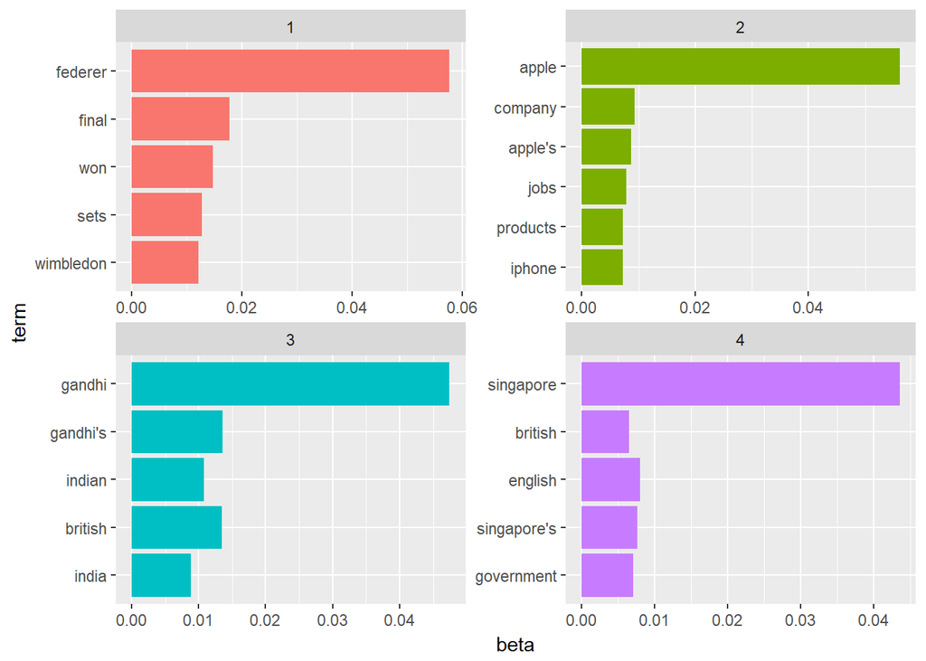

```r
top_terms %>%
  mutate(term = reorder(term, beta)) %>%
  ggplot(aes(term, beta, fill = factor(topic))) +
  geom_col(show.legend = FALSE) +
  facet_wrap(~ topic, scales = "free") +
  coord_flip()
```

### Analysing document-topic mappings

Now, we are analysing document topic mappings. We may want to know which topics are associated with each document.

Can we put the sentences back together in the correct documents? Or could we find out which sentence belongs to which document? We can find this by examining the per-document-per-topic probabilities, “gamma”.

Following is the gamma analysis:

```r
docs_gamma <- tidy(documents_lda, matrix = "gamma")
docs_gamma    # A tibble: 772 x 3
```

```
## # A tibble: 1,516 x 3
##    document          topic    gamma
##    <chr>             <int>    <dbl>
##  1 Apple_104             1 0.000313
##  2 RogerFederer_55       1 0.999
##  3 Apple_136             1 0.000416
##  4 Apple_54              1 0.000249
##  5 Apple_12              1 0.000511
##  6 Apple_149             1 0.000422
##  7 Apple_66              1 0.000532
##  8 Apple_76              1 0.000759
##  9 MahatmaGandhi_111     1 0.000578
## 10 MahatmaGandhi_139     1 0.000885
## # ... with 1,506 more rows
```

```r
# re-separate the document name into title and chapter
docs_gamma <- docs_gamma %>%
  separate(document, c("title", "DocNum"), sep = "_", convert = TRUE)

docs_gamma
```

```
## # A tibble: 1,516 x 4
##    title         DocNum topic    gamma
##    <chr>          <int> <int>    <dbl>
##  1 Apple            104     1 0.000313
##  2 RogerFederer      55     1 0.999
##  3 Apple            136     1 0.000416
##  4 Apple             54     1 0.000249
##  5 Apple             12     1 0.000511
##  6 Apple            149     1 0.000422
##  7 Apple             66     1 0.000532
##  8 Apple             76     1 0.000759
##  9 MahatmaGandhi    111     1 0.000578
## 10 MahatmaGandhi    139     1 0.000885
## # ... with 1,506 more rows
```

How this could be interpreted? This could be understand as - each gamma value is an estimated proportion of words from that document that are generated from that topic.

Now that we have these topic probabilities, we can see how well our **unsupervised learning** did.

Also, we can visualize the per-document-per-topic probability for each topic.

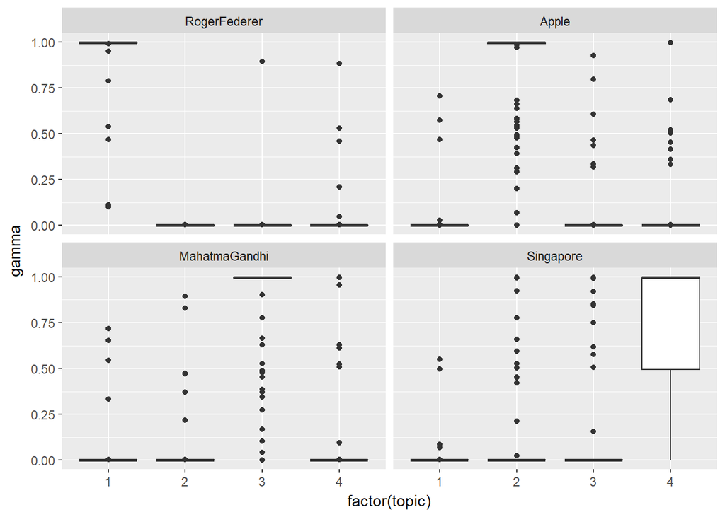

```r
docs_gamma %>%
  mutate(title = reorder(title, gamma * topic)) %>%
  ggplot(aes(factor(topic), gamma)) +
  geom_boxplot() +
  facet_wrap(~ title)
```

### Classifying Documents using Model Output

In the below chunk of code, we first find the topic that was most associated with a document using ’top_n(1)`, which is effectively the “classification” of that document.

```r
document_classifications <- docs_gamma %>%
  group_by(title, DocNum) %>%
  top_n(1, gamma) %>%
  ungroup()

document_classifications
```

```
## # A tibble: 379 x 4
##    title        DocNum topic gamma
##    <chr>         <int> <int> <dbl>
##  1 RogerFederer     55     1 0.999
##  2 RogerFederer      2     1 0.999
##  3 RogerFederer     83     1 0.998
##  4 RogerFederer    105     1 0.998
##  5 RogerFederer    120     1 0.999
##  6 RogerFederer     18     1 0.998
##  7 RogerFederer     49     1 0.999
##  8 RogerFederer     51     1 0.952
##  9 RogerFederer      6     1 0.999
## 10 RogerFederer      8     1 0.998
## # ... with 369 more rows
```

Now, let us compare what the model estimated against the “known” topic assignments (that’s what a simulation is actually - where we know the true values in advance in order to assess the validity of the method being tested).

```r
docs_topics <- document_classifications %>%
  count(title, topic) %>%
  group_by(title) %>%
  top_n(1, n) %>%
  ungroup() %>%
  transmute(consensus = title, topic)

docs_topics    # A tibble: 4 x 2
```

```
## # A tibble: 4 x 2
##   consensus     topic
##   <chr>         <int>
## 1 Apple             2
## 2 MahatmaGandhi     3
## 3 RogerFederer      1
## 4 Singapore         4
```

```r
# find 'em mismatches now.
document_classifications %>%
  inner_join(docs_topics, by = "topic") %>%
  filter(title != consensus)
```

```
## # A tibble: 51 x 5
##    title         DocNum topic gamma consensus
##    <chr>          <int> <int> <dbl> <chr>
##  1 Apple             89     1 0.575 RogerFederer
##  2 Apple            139     1 0.706 RogerFederer
##  3 MahatmaGandhi      5     1 0.652 RogerFederer
##  4 Singapore        100     1 0.551 RogerFederer
##  5 MahatmaGandhi    141     1 0.543 RogerFederer
##  6 MahatmaGandhi     28     1 0.716 RogerFederer
##  7 Singapore         23     2 0.658 Apple
##  8 Singapore         10     2 0.528 Apple
##  9 Singapore        134     2 0.502 Apple
## 10 Singapore         32     2 0.776 Apple
## # ... with 41 more rows
```

```r
document_classifications
```

```
## # A tibble: 379 x 4
##    title        DocNum topic gamma
##    <chr>         <int> <int> <dbl>
##  1 RogerFederer     55     1 0.999
##  2 RogerFederer      2     1 0.999
##  3 RogerFederer     83     1 0.998
##  4 RogerFederer    105     1 0.998
##  5 RogerFederer    120     1 0.999
##  6 RogerFederer     18     1 0.998
##  7 RogerFederer     49     1 0.999
##  8 RogerFederer     51     1 0.952
##  9 RogerFederer      6     1 0.999
## 10 RogerFederer      8     1 0.998
## # ... with 369 more rows
```

### Assessing and Visualizing Model Performance

```r
assignments <- augment(documents_lda, data = documents_dtm)
assignments    # tibble: 104,721 x 4. cols={doc, term, count, .topic}
```

```
## # A tibble: 11,784 x 4
##    document  term  count .topic
##    <chr>     <chr> <dbl>  <dbl>
##  1 Apple_104 apple    7.     2.
##  2 Apple_136 apple    6.     2.
##  3 Apple_54  apple    6.     2.
##  4 Apple_12  apple    5.     2.
##  5 Apple_149 apple    5.     2.
##  6 Apple_66  apple    5.     2.
##  7 Apple_76  apple    5.     2.
##  8 Apple_110 apple    4.     2.
##  9 Apple_119 apple    4.     2.
## 10 Apple_120 apple    4.     2.
## # ... with 11,774 more rows
```

```r
# combine assignments table with consensus document titles to find incorrectly classified words.

assignments <- assignments %>%
  separate(document, c("title", "DocNum"), sep = "_", convert = TRUE) %>%
  inner_join(docs_topics, by = c(".topic" = "topic"))

assignments
```

```
## # A tibble: 11,784 x 6
##    title DocNum term  count .topic consensus
##    <chr>  <int> <chr> <dbl>  <dbl> <chr>
##  1 Apple    104 apple    7.     2. Apple
##  2 Apple    136 apple    6.     2. Apple
##  3 Apple     54 apple    6.     2. Apple
##  4 Apple     12 apple    5.     2. Apple
##  5 Apple    149 apple    5.     2. Apple
##  6 Apple     66 apple    5.     2. Apple
##  7 Apple     76 apple    5.     2. Apple
##  8 Apple    110 apple    4.     2. Apple
##  9 Apple    119 apple    4.     2. Apple
## 10 Apple    120 apple    4.     2. Apple
## # ... with 11,774 more rows
```

This combination of the true document (title) and the document assigned to it (consensus) is useful for further exploration.

We can, for example, visualize a *confusion matrix*, showing how often words from one document were assigned to another, using dplyr’s `count()` and ggplot2’s `geom_tile`.

### Confusion Matrix

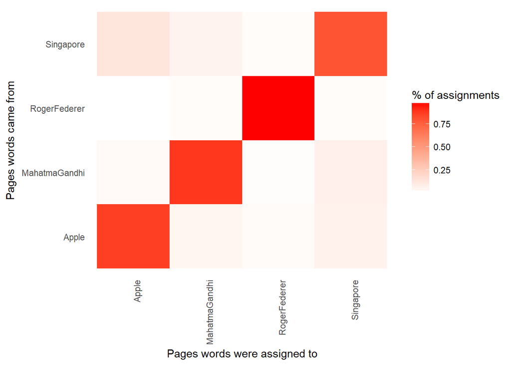

```r
assignments %>%
  count(title, consensus, wt = count) %>%
  group_by(title) %>%
  mutate(percent = n / sum(n))%>%
  ggplot(aes(consensus, title, fill = percent)) +
  geom_tile() +
  scale_fill_gradient2(high = "red") +  # , label = percent_format()
  theme_minimal() +
  theme(axis.text.x = element_text(angle = 90, hjust = 1),
        panel.grid = element_blank()) +
  labs(x = "Pages words were assigned to",
       y = "Pages words came from",
       fill = "% of assignments")
```

The below chunk of code will determine what were the most commonly mistaken words?

```r
wrong_words <- assignments %>%
  filter(title != consensus)

wrong_words
```

```
## # A tibble: 1,519 x 6
##    title         DocNum term     count .topic consensus
##    <chr>          <int> <chr>    <dbl>  <dbl> <chr>
##  1 Singapore         93 british     1.     3. MahatmaGandhi
##  2 MahatmaGandhi     81 british     1.     4. Singapore
##  3 Singapore         67 british     1.     3. MahatmaGandhi
##  4 Apple             78 german      1.     1. RogerFederer
##  5 MahatmaGandhi     79 times       1.     4. Singapore
##  6 RogerFederer      51 english     1.     4. Singapore
##  7 Singapore         23 internet    2.     2. Apple
##  8 Singapore         10 internet    2.     2. Apple
##  9 Singapore         32 internet    1.     2. Apple
## 10 Singapore         66 internet    1.     2. Apple
## # ... with 1,509 more rows
```